# Predicting Personal Loan Acceptance for Universal Bank

This project uses customer demographic and financial data from Universal Bank to build machine learning models that predict whether a customer will accept a personal loan offer.

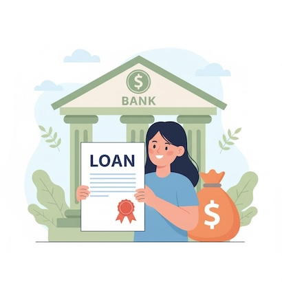

## Section 1 — Project Overview

### 1.1 Dataset and Problem Description

- Indicate **which dataset** you selected (name and source).
> - **Dataset Name:** Universal Bank Personal Loan Dataset
> - **Source:** [Kaggle – Bank Personal Loan Machine Learning Project](https://www.kaggle.com/code/sharped/bank-personal-loan-machine-learning-project)
- Describe **the size of the dataset** (number of rows and columns).
> - **Number of rows (observations):** 5,012
> - **Number of columns (variables):** 12
- Introduce **all variables**: provide a short description of each key variable and its meaning.
> - **Age:** Customer’s age (in years)
> - **Experience:** Number of years of professional experience
> - **Income:** Annual income of the customer (in thousands)
> - **Family:** Family size (1 = single, 2 = married couple, etc.)
> - **CCAvg:** Average monthly spending on credit cards (in thousands)
> - **Education:** Education level (1 = Undergraduate, 2 = Graduate, 3 = Advanced/Professional)
> - **Mortgage:** Value of mortgage if any (in thousands)
> - **Personal_Loan:** Target variable — whether the customer accepted the personal loan offer (1 = Yes, 0 = No)
> - **Securities_Account:** Whether the customer has a securities account with the bank (1 = Yes, 0 = No)
> - **CD_Account:** Whether the customer holds a certificate of deposit account (1 = Yes, 0 = No)
> - **Online:** Whether the customer uses online banking services (1 = Yes, 0 = No)
> - **CreditCard:** Whether the customer has a credit card issued by the bank (1 = Yes, 0 = No)

### 1.2 Business Motivation

- What is the **business problem** you are trying to solve?

> Universal Bank is a financial institution that offers various services such as savings accounts, credit cards, and investment products.  
> To increase revenue and strengthen customer relationships, the bank recently launched a **personal loan marketing campaign**.  
> However, only a small portion of customers accepted the offer, suggesting that the campaign may not have effectively reached the right audience. The business goal is to **identify which customers are most likely to accept a personal loan offer** based on their demographic and financial characteristics.  
> By accurately predicting loan acceptance, the bank can:
> - Improve the efficiency of future marketing campaigns.
> - Reduce unnecessary marketing costs.
> - Better understand the behavioral patterns of high-value customers.
> - Enhance overall customer targeting and relationship management.
- Who are the **stakeholders** involved (e.g., managers, teams, customers)?

> **Marketing Managers:**  
> Responsible for designing and executing personal loan campaigns.  
> They will use the model’s predictions to identify high-potential customers and optimize marketing budgets.

> **Product and Retail Banking Teams:**  
> Oversee customer relationship management and cross-selling strategies.  
> They can use insights to refine product positioning and improve customer engagement.

> **Data Analytics / Data Science Team:**  
> Develop, validate, and maintain predictive models.  
> They ensure the analysis is accurate, interpretable, and aligned with business goals.

> **Senior Management / Executives:**  
> Use model insights to make strategic decisions about marketing investments and customer segmentation.

> **Customers:**  
> Indirect stakeholders who benefit from more relevant and personalized offers rather than generic promotions.
- What are the **potential benefits or costs of not solving** this problem?

> **Potential Benefits:**
> - **Improved marketing efficiency:** The bank can focus its campaigns on customers most likely to accept the personal loan offer.
> - **Reduced acquisition costs:** Fewer resources wasted on uninterested customers, improving return on marketing investment (ROI).
> - **Enhanced customer relationships:** More relevant and personalized offers increase satisfaction and long-term loyalty.
> - **Data-driven decision-making:** Provides measurable insights that can guide future product launches and targeting strategies.

> **Potential Costs of Not Solving the Problem:**
> - **Inefficient marketing campaigns:** Continued spending on broad, untargeted offers with low conversion rates.
> - **Lost revenue opportunities:** Missing out on customers who are likely to accept loans but were not properly identified.
> - **Customer fatigue:** Overexposing uninterested customers to irrelevant promotions, potentially harming brand perception.
> - **Competitive disadvantage:** Other banks using analytics may outperform Universal Bank in customer acquisition and retention.

## Section 2 — EDA (Data Understanding & Key Insights)

Use this section to **understand your dataset and uncover key business-relevant patterns.** Feel free to include both tables and visualizations.

1. Mount your Google Drive.
2. Set your working directory (if you’re using the default, no changes are needed).
3. Update the file name to match the dataset you selected.

```python
from google.colab import drive
drive.mount('/content/drive')

# Verify the current working directory
import os
print(f"Current working directory: {os.getcwd()}")

# Change working directory based on your preference. Mine is the directory named 'Colab Notebooks' in MyDrive)
%cd /content/drive/MyDrive/Colab Notebooks

# Print out current working directory
print(f"Current working directory: {os.getcwd()}")

# Read data into jupyter notebook
import pandas as pd

# Read File
df = pd.read_csv("FinalProject_UniversalBank.csv") # Change the file name to your own dataset
```

```
Current working directory: /content/drive/My Drive/Colab Notebooks
/content/drive/MyDrive/Colab Notebooks
Current working directory: /content/drive/MyDrive/Colab Notebooks
```

### 2.1 Dataset Overview

- Provide a clear, high-level description of the dataset.

```python
# === View a sample of the dataset ===
df.head()  # Inspect first few rows to understand structure and format

# === Dataset dimensions ===
print("Number of rows:", df.shape[0])
print("Number of columns:", df.shape[1])
print("\n" + "-"*50)

# === Column names ===
print("Column names:")
print(df.columns.tolist())
print("\n" + "-"*50)

# === Data types summary ===
df.info()  # Shows variable types and count of non-null entries
print("\n" + "-"*50)

# === Descriptive statistics for numerical features ===
df.describe().T  # Transpose for easier reading
```

```
Number of rows: 5012
Number of columns: 12

--------------------------------------------------
Column names:
['Age', 'Experience', 'Income', 'Family', 'CCAvg', 'Education', 'Mortgage', 'Securities Account', 'CD Account', 'Online', 'CreditCard', 'Personal Loan']

--------------------------------------------------
<class 'pandas.core.frame.DataFrame'>
RangeIndex: 5012 entries, 0 to 5011
Data columns (total 12 columns):
 #   Column              Non-Null Count  Dtype
---  ------              --------------  -----
 0   Age                 5012 non-null   int64
 1   Experience          5012 non-null   int64
 2   Income              5009 non-null   float64
 3   Family              5010 non-null   float64
 4   CCAvg               5009 non-null   float64
 5   Education           5012 non-null   int64
 6   Mortgage            5009 non-null   float64
 7   Securities Account  5010 non-null   float64
 8   CD Account          5011 non-null   float64
 9   Online              5012 non-null   int64
 10  CreditCard          5011 non-null   float64
 11  Personal Loan       5012 non-null   int64
dtypes: float64(7), int64(5)
memory usage: 470.0 KB

--------------------------------------------------
```

|  | count | mean | std | min | 25% | 50% | 75% | max |
| --- | --- | --- | --- | --- | --- | --- | --- | --- |
| Age | 5012.0 | 45.284517 | 11.565871 | -10.0 | 35.0 | 45.0 | 55.0 | 67.0 |
| Experience | 5012.0 | 20.099162 | 11.478470 | -3.0 | 10.0 | 20.0 | 30.0 | 43.0 |
| Income | 5009.0 | 73.735077 | 46.083580 | -22.0 | 39.0 | 64.0 | 98.0 | 224.0 |
| Family | 5010.0 | 2.396208 | 1.147926 | 1.0 | 1.0 | 2.0 | 3.0 | 4.0 |
| CCAvg | 5009.0 | 1.937579 | 1.747941 | 0.0 | 0.7 | 1.5 | 2.5 | 10.0 |
| Education | 5012.0 | 1.881684 | 0.840128 | 1.0 | 1.0 | 2.0 | 3.0 | 3.0 |
| Mortgage | 5009.0 | 56.414254 | 101.519887 | 0.0 | 0.0 | 0.0 | 101.0 | 635.0 |
| Securities Account | 5010.0 | 0.104192 | 0.305539 | 0.0 | 0.0 | 0.0 | 0.0 | 1.0 |
| CD Account | 5011.0 | 0.060068 | 0.237636 | 0.0 | 0.0 | 0.0 | 0.0 | 1.0 |
| Online | 5012.0 | 0.596768 | 0.490596 | 0.0 | 0.0 | 1.0 | 1.0 | 1.0 |
| CreditCard | 5011.0 | 0.294153 | 0.455706 | 0.0 | 0.0 | 0.0 | 1.0 | 1.0 |
| Personal Loan | 5012.0 | 0.095770 | 0.294305 | 0.0 | 0.0 | 0.0 | 0.0 | 1.0 |

### 2.2 Data Quality

- Diagnose and handle data problems that could affect analysis.

```python
# === Check for missing values ===
print("\n=== Missing Values ===")
missing_counts = df.isna().sum()
if missing_counts.sum() > 0:
    print("Columns with missing values:")
    print(missing_counts[missing_counts > 0])
    print("\nRemoving rows with missing values...")
    df = df.dropna()  # remove rows with missing values
    print(f"Missing values removed. New dataset shape: {df.shape}")
else:
    print("No missing values found.")
print("\n" + "-"*50)

# === Check for duplicate rows ===
print("\n=== Duplicate Rows ===")
num_duplicates = df.duplicated().sum()
print(f"Number of duplicate rows: {num_duplicates}")

if num_duplicates > 0:
    print("Removing duplicate rows...")
    df = df.drop_duplicates()
    print(f"Duplicates removed. New dataset shape: {df.shape}")
else:
    print("No duplicate rows found.")
print("\n" + "-"*50)


# === Check for impossible or out-of-range values ===
print("\n=== Check for Impossible or Out-of-Range Values ===")

if 'Age' in df.columns:
    invalid_age = df[df['Age'] < 0]
    print(f"Invalid ages found: {len(invalid_age)}")
    if len(invalid_age) > 0:
        df = df[df['Age'] >= 0]
        print("Negative ages removed.")
else:
    print("No Age column found.")

if 'Income' in df.columns:
    invalid_income = df[df['Income'] < 0]
    print(f"Invalid income values found: {len(invalid_income)}")
    if len(invalid_income) > 0:
        df = df[df['Income'] >= 0]
        print("Negative income values removed.")
else:
    print("No Income column found.")
print("\n" + "-"*50)

# === Detect potential outliers (numeric columns only) ===
print("\n=== Outlier Detection (IQR Method) ===")
numeric_cols = df.select_dtypes(include=['int64', 'float64']).columns

for col in numeric_cols:
    Q1 = df[col].quantile(0.25)
    Q3 = df[col].quantile(0.75)
    IQR = Q3 - Q1
    lower_bound = Q1 - 1.5 * IQR
    upper_bound = Q3 + 1.5 * IQR
    outlier_count = df[(df[col] < lower_bound) | (df[col] > upper_bound)].shape[0]
    if outlier_count > 0:
        print(f"{col}: {outlier_count} potential outliers")
print("\n" + "-"*50)


print("\nData Quality Check and Basic Cleaning Completed.")
print(f"Final dataset shape: {df.shape}")
print("Next step: proceed to 2.3 Descriptive Exploration.")
```

```
=== Missing Values ===
Columns with missing values:
Income                3
Family                2
CCAvg                 3
Mortgage              3
Securities Account    2
CD Account            1
CreditCard            1
dtype: int64

Removing rows with missing values...
Missing values removed. New dataset shape: (4997, 12)

--------------------------------------------------

=== Duplicate Rows ===
Number of duplicate rows: 24
Removing duplicate rows...
Duplicates removed. New dataset shape: (4973, 12)

--------------------------------------------------

=== Check for Impossible or Out-of-Range Values ===
Invalid ages found: 4
Negative ages removed.
Invalid income values found: 2
Negative income values removed.

--------------------------------------------------

=== Outlier Detection (IQR Method) ===
Income: 95 potential outliers
CCAvg: 301 potential outliers
Mortgage: 290 potential outliers
Securities Account: 518 potential outliers
CD Account: 301 potential outliers
Personal Loan: 480 potential outliers

--------------------------------------------------

Data Quality Check and Basic Cleaning Completed.
Final dataset shape: (4967, 12)
Next step: proceed to 2.3 Descriptive Exploration.
```

### 2.3 Descriptive Explorations

- The goal of data exploration is to **discover patterns, relationships, and stories** within your data before modeling. This step is not about following fixed rules — it’s about curiosity, creativity, and developing intuition. You are encouraged to **freely explore** the data in ways that make sense for your project — visualize, compare, or test relationships.

```
=== 2.3 Data Exploration ===

Note: The following are suggested analyses. Feel free to pick, reorder, or add your own.

------------------------------------------------------------
Numeric columns detected: ['Age', 'Experience', 'Income', 'CCAvg', 'Mortgage', 'Securities Account', 'CD Account', 'Personal Loan']
Categorical-like columns detected (for grouping/plots): ['Family', 'Education', 'Online', 'CreditCard']

------------------------------------------------------------

1) Distributions of numeric features (histograms + skewness)
```

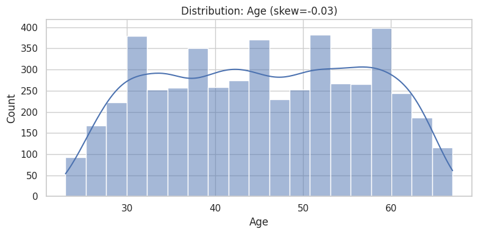

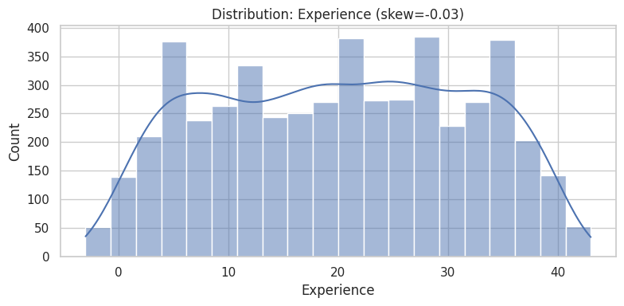

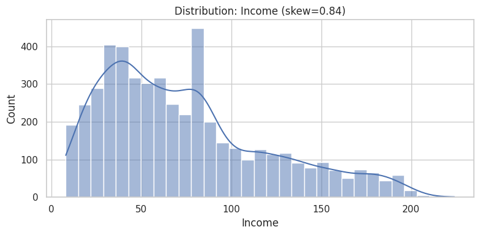

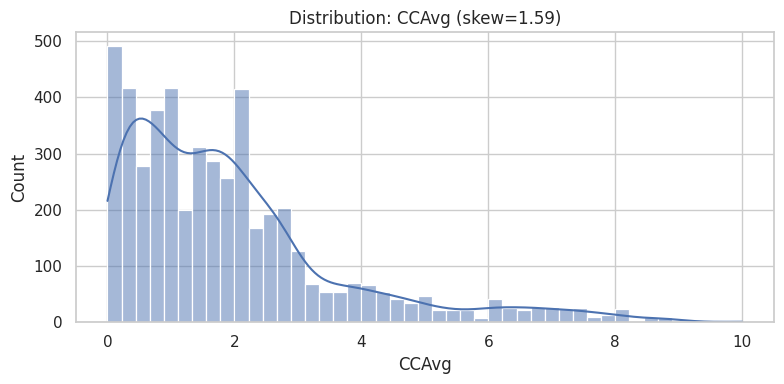

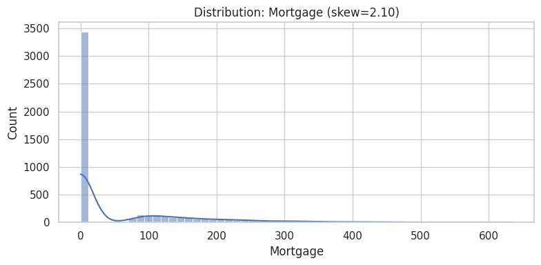

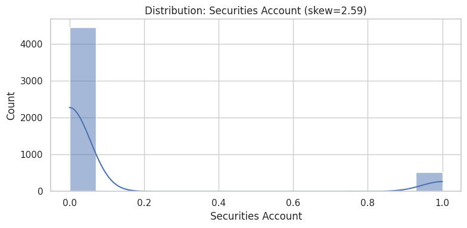

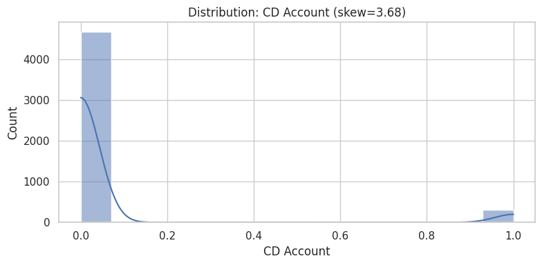

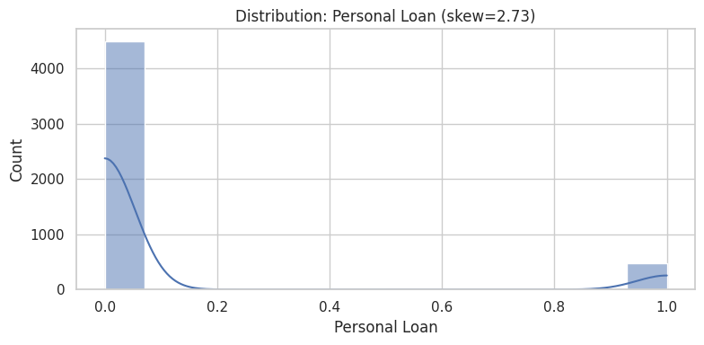

```
Completed numeric distributions.
------------------------------------------------------------

2) Boxplots for key numeric features (quick outlier check)
```

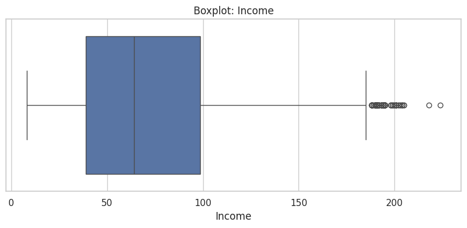

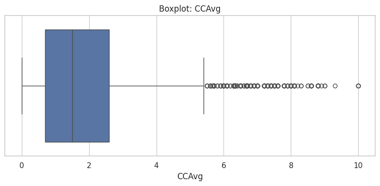

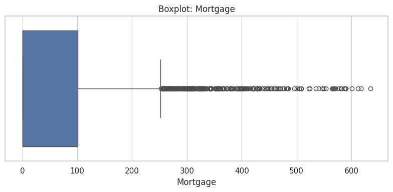

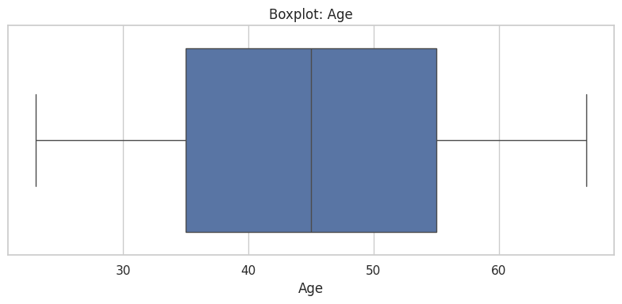

```
Completed boxplots.
------------------------------------------------------------

3) Scatterplots for selected feature pairs
```

[13 more figures not shown]

```
------------------------------------------------------------

7) Skewness checks and transform suggestions

CCAvg: skew=1.59 -> Consider log or Box-Cox transform
Mortgage: skew=2.10 -> Consider log or Box-Cox transform
Securities Account: skew=2.59 -> Consider log or Box-Cox transform
CD Account: skew=3.68 -> Consider log or Box-Cox transform
Personal Loan: skew=2.73 -> Consider log or Box-Cox transform

------------------------------------------------------------

8) Outlier inspection (showing top extreme rows for selected columns)

Top 5 by Income:
```

|  | Income |
| --- | --- |
| 3896 | 224.0 |
| 4993 | 218.0 |
| 2988 | 205.0 |
| 526 | 205.0 |
| 4225 | 204.0 |

```
Top 5 by CCAvg:
```

|  | CCAvg |
| --- | --- |
| 787 | 10.0 |
| 2101 | 10.0 |
| 2337 | 10.0 |
| 3943 | 9.3 |
| 3822 | 9.0 |

```
Top 5 by Mortgage:
```

|  | Mortgage |
| --- | --- |
| 2934 | 635.0 |
| 303 | 617.0 |
| 4812 | 612.0 |
| 1783 | 601.0 |
| 4842 | 590.0 |

```
Top 5 by Age:
```

|  | Age |
| --- | --- |
| 2846 | 67 |
| 4468 | 67 |
| 4451 | 67 |
| 4360 | 67 |
| 3331 | 67 |

```
------------------------------------------------------------

9) Group-level summaries (example: Education)
```

| Education | Income count | Income mean | Income median | CCAvg count | CCAvg mean | CCAvg median | Mortgage count | Mortgage mean | Mortgage median |
| --- | --- | --- | --- | --- | --- | --- | --- | --- | --- |
| 1 | 2088 | 85.60 | 79.0 | 2088 | 2.26 | 1.7 | 2088 | 61.52 | 0.0 |
| 2 | 1392 | 64.52 | 54.0 | 1392 | 1.69 | 1.5 | 1392 | 51.53 | 0.0 |
| 3 | 1487 | 66.29 | 59.0 | 1487 | 1.73 | 1.4 | 1487 | 54.41 | 0.0 |

```
------------------------------------------------------------

10) Feature engineering suggestions (create and inspect briefly)

Created 'Income_per_member' (Income / Family). Summary:
```

|  | Income_per_member |
| --- | --- |
| count | 4967.00 |
| mean | 42.49 |
| std | 39.54 |
| min | 2.00 |
| 25% | 15.00 |
| 50% | 27.25 |
| 75% | 58.00 |
| max | 205.00 |

**dtype:** float64

```
Created 'log_CCAvg' as log(1 + CCAvg). Check mean/skew:
```

|  | log_CCAvg |
| --- | --- |
| count | 4967.00 |
| mean | 0.93 |
| std | 0.53 |
| min | 0.00 |
| 25% | 0.53 |
| 50% | 0.92 |
| 75% | 1.28 |
| max | 2.40 |

**dtype:** float64

```python
# --- imports (add these at top of notebook if not already present) ---
import pandas as pd
import numpy as np
import matplotlib.pyplot as plt
import seaborn as sns
from IPython.display import display

sns.set(style="whitegrid", context="notebook")
plt.rcParams.update({"figure.figsize": (8, 4)})


print("\n=== 2.3 Data Exploration ===\n")
print("Note: The following are suggested analyses. Feel free to pick, reorder, or add your own.\n")
print("-" * 60)


# ---------------------------
# Helper lists and checks
# ---------------------------
numeric_cols = df.select_dtypes(include=["int64", "float64"]).columns.tolist()
categorical_cols = df.select_dtypes(include=["object", "category", "bool"]).columns.tolist()

# In Universal Bank, many binary flags are int; treat small integers as categorical if appropriate
# e.g., if columns exist convert: 'Family','Education','Securities_Account','CD_Account','Online','CreditCard'
possible_cat = ["Family", "Education", "Securities_Account", "CD_Account", "Online", "CreditCard", "Personal_Loan"]
for c in possible_cat:
    if c in df.columns and c not in categorical_cols:
        # treat as category for plotting purposes
        categorical_cols.append(c)
        if c in numeric_cols:
            numeric_cols.remove(c)

print("Numeric columns detected:", numeric_cols)
print("Categorical-like columns detected (for grouping/plots):", categorical_cols)
print("\n" + "-" * 60)


# ---------------------------
# 1) Distributions for numeric features
# ---------------------------
print("\n1) Distributions of numeric features (histograms + skewness)\n")
for col in numeric_cols:
    plt.figure()
    sns.histplot(df[col].dropna(), kde=True)
    plt.title(f"Distribution: {col} (skew={df[col].skew():.2f})")
    plt.xlabel(col)
    plt.ylabel("Count")
    plt.tight_layout()
    plt.show()

print("\nCompleted numeric distributions.\n" + "-" * 60)


# ---------------------------
# 2) Boxplots to inspect spread / outliers for key numeric features
# ---------------------------
print("\n2) Boxplots for key numeric features (quick outlier check)\n")
key_numeric = ["Income", "CCAvg", "Mortgage", "Age"]  # adjust as available
for col in key_numeric:
    if col in df.columns:
        plt.figure()
        sns.boxplot(x=df[col])
        plt.title(f"Boxplot: {col}")
        plt.tight_layout()
        plt.show()

print("\nCompleted boxplots.\n" + "-" * 60)


# ---------------------------
# 3) Relationship between features (scatterplots) - pick interesting pairs
# ---------------------------
print("\n3) Scatterplots for selected feature pairs\n")
pairs = [("Income", "CCAvg"), ("Age", "Income"), ("Experience", "Income")]
for x, y in pairs:
    if x in df.columns and y in df.columns:
        plt.figure()
        sns.scatterplot(x=df[x], y=df[y], alpha=0.6)
        plt.title(f"{y} vs {x}")
        plt.xlabel(x)
        plt.ylabel(y)
        plt.tight_layout()
        plt.show()

print("\nCompleted selected scatterplots.\n" + "-" * 60)


# ---------------------------
# 4) Pairplot for a small subset (careful: can be slow for many columns)
# ---------------------------
print("\n4) Pairplot for a subset of numeric features (sample if large)\n")
pair_subset = [c for c in ["Age", "Income", "CCAvg", "Mortgage"] if c in df.columns]
if len(pair_subset) >= 2:
    # sample to speed up if dataset is big
    sample_df = df[pair_subset].sample(n=min(1000, len(df)), random_state=42)
    sns.pairplot(sample_df)
    plt.suptitle("Pairplot (sample)", y=1.02)
    plt.show()
else:
    print("Not enough columns for pairplot.")
print("\n" + "-" * 60)


# ---------------------------
# 5) Compare target across categories (bar / box plots)
# ---------------------------
print("\n5) Target variable by categorical features\n")
target = "Personal Loan" if "Personal Loan" in df.columns else None
if target:
    for cat in categorical_cols:
        if cat == target:
            continue
        if cat in df.columns:
            plt.figure()
            # compute average loan acceptance rate by category
            counts = df.groupby(cat)[target].mean().sort_values()
            counts.plot(kind="bar")
            plt.ylabel(f"Mean({target})")
            plt.title(f"Average {target} by {cat}")
            plt.tight_layout()
            plt.show()

            # also show count distribution for context
            plt.figure()
            sns.countplot(x=cat, data=df)
            plt.title(f"Count by {cat}")
            plt.xticks(rotation=45)
            plt.tight_layout()
            plt.show()
else:
    print("No target column named 'Personal Loan' found for grouped plots.")
print("\n" + "-" * 60)


# ---------------------------
# 6) Correlation matrix (numeric)
# ---------------------------
print("\n6) Correlation matrix (numeric features)\n")
if len(numeric_cols) >= 2:
    corr = df[numeric_cols].corr().round(2)
    plt.figure(figsize=(10, 8))
    sns.heatmap(corr, annot=True, cmap="coolwarm", center=0)
    plt.title("Correlation Matrix (numeric columns)")
    plt.tight_layout()
    plt.show()
else:
    print("Not enough numeric columns for correlation matrix.")
print("\n" + "-" * 60)


# ---------------------------
# 7) Skewness & simple transform suggestions
# ---------------------------
print("\n7) Skewness checks and transform suggestions\n")
skewed = {}
for col in numeric_cols:
    s = df[col].dropna().skew()
    if abs(s) > 1:
        skewed[col] = s
        print(f"{col}: skew={s:.2f} -> Consider log or Box-Cox transform")
if not skewed:
    print("No strongly skewed numeric columns detected (abs(skew) <= 1).")
print("\n" + "-" * 60)


# ---------------------------
# 8) Outlier inspection: show top records for suspicious numeric values
# ---------------------------
print("\n8) Outlier inspection (showing top extreme rows for selected columns)\n")
for col in key_numeric:
    if col in df.columns:
        top = df.sort_values(by=col, ascending=False).head(5)[["ID", col]] if "ID" in df.columns else df.sort_values(by=col, ascending=False).head(5)[[col]]
        print(f"Top 5 by {col}:")
        display(top)
        print()

print("\n" + "-" * 60)


# ---------------------------
# 9) Segmentation / group-level summaries (example: by Education)
# ---------------------------
print("\n9) Group-level summaries (example: Education)\n")
if "Education" in df.columns:
    display(df.groupby("Education")[["Income", "CCAvg", "Mortgage"]].agg(["count", "mean", "median"]).round(2))
else:
    print("No Education column found.")
print("\n" + "-" * 60)


# ---------------------------
# 10) Feature engineering ideas (examples)
# ---------------------------
print("\n10) Feature engineering suggestions (create and inspect briefly)\n")
# Example: income per family member (if Family exists)
if set(["Income", "Family"]).issubset(df.columns):
    df["Income_per_member"] = df["Income"] / df["Family"].replace(0, np.nan)
    print("Created 'Income_per_member' (Income / Family). Summary:")
    display(df["Income_per_member"].describe().round(2))
else:
    print("Income_per_member not created (missing Income or Family).")

# Example: log transform suggestion for high-skew variable
if "CCAvg" in df.columns:
    df["log_CCAvg"] = np.log1p(df["CCAvg"])
    print("Created 'log_CCAvg' as log(1 + CCAvg). Check mean/skew:")
    display(df["log_CCAvg"].describe().round(2))

print("\n" + "-" * 60)
```

### 2.4 Insights

In this section, summarize **what you discovered** from your data exploration (Section 2.3).  
Your goal is to **translate observations into insights** that connect back to your business question.

> **Which variables seem most influential or interesting?**
> - *Income*, *CCAvg*, and *Education* appear to be the most influential predictors.
> - *Family size* and *Age* add demographic depth but show weaker direct influence.
> - The derived variable *Income_per_member* also provides a more precise measure of household financial capacity.

> **Did you notice any unexpected relationships or trends?**
> - Despite expectations, not all high-income customers accepted the loan — suggesting that **income alone is not sufficient**; marketing communication or risk perception might also play a role.
> - *Mortgage* showed limited direct correlation with loan acceptance, which may indicate that customers already carrying debt are less interested in new loans.
> - *Education* seems to drive acceptance more strongly than *Age*, highlighting that **knowledge and financial literacy** may be stronger predictors than demographic maturity.

> **What do these findings imply for business decisions?**
> - The bank can **target marketing efforts** toward high-income, high-spending, and well-educated customers to increase acceptance rates.
> - Campaign messaging could emphasize **financial flexibility and tailored loan offers** rather than basic credit availability.
> - Customer segmentation based on spending behavior and education may improve marketing ROI.

## Section 3 — Modeling & Evaluation

### 3.1 Problem Type and Setup

- State whether this is a **supervised** or **unsupervised** task.
- List the **features** you selected and explain briefly why.
- How did you split or sample your data (e.g., train/test, cross-validation)?

```python
# ============================================================
# 4.1 Modeling Setup
# ============================================================
# 💡 Guidance:
# - Exercise your own judgment on what models are most relevant.
# - You may skip, expand, or adjust parts as appropriate.
# - Feel free to remove this instructional part when finalizing your project.
# ============================================================


# ------------------------------------------------------------
# 4.1.1 Task Type
# ------------------------------------------------------------
# This is a **supervised classification** task.
# Target variable (y): "Personal Loan" — indicates whether a customer accepted
# the bank’s personal loan offer (1 = Yes, 0 = No).
# Goal: Predict which customers are most likely to accept the offer.
#
# Why this approach fits:
# - The target variable is known and binary → classification is appropriate.
# - Predicting customer acceptance helps marketing managers identify
#   high-potential customers and reduce campaign costs.
# ------------------------------------------------------------

# Define target and features
target = "Personal Loan"
X = df.drop(columns=[target])
y = df[target]

print("Task Type: Supervised Classification")
print(f"Target variable: {target}")
print(f"Shape of X: {X.shape}")
print(f"Shape of y: {y.shape}")
print("\n" + "-"*50)


# ------------------------------------------------------------
# 4.1.2 Feature Selection
# ------------------------------------------------------------
# Selected key features (independent variables):
#   - Income: indicator of financial capacity.
#   - CCAvg: monthly average credit card spending, proxy for spending behavior.
#   - Education: level of financial literacy and earning potential.
#   - Family: household size, may affect borrowing needs.
#   - Age: stage in career and financial life cycle.
#   - Mortgage: existing home loan amount.
#   - Securities Account / CD Account / Online / CreditCard: reflect product
#     engagement and digital behavior with the bank.
#
# Rationale:
# - These variables capture both financial status and customer engagement.
# - Demographic + behavioral features together improve prediction accuracy.
# ------------------------------------------------------------

selected_features = [
    "Age",
    "Experience",
    "Income",
    "Family",
    "CCAvg",
    "Education",
    "Mortgage",
    "Securities Account",
    "CD Account",
    "Online",
    "CreditCard",
    "Income_per_member",
    "log_CCAvg"
]

X = df[selected_features]
print("Selected Features for Modeling:")
for f in selected_features:
    print("-", f)
print("\n" + "-"*50)


# ------------------------------------------------------------
# 4.1.3 Data Splitting or Sampling
# ------------------------------------------------------------
# We'll divide the dataset into training and testing sets for fair evaluation.
# - 80% of the data used for training the models.
# - 20% reserved for testing (unseen data).
# - random_state ensures reproducibility.
#
# Note: Because the target is binary, stratify=y keeps class balance in both sets.
# ------------------------------------------------------------

from sklearn.model_selection import train_test_split

X_train, X_test, y_train, y_test = train_test_split(
    X, y, test_size=0.2, random_state=42, stratify=y
)

print("Data Split Completed")
print(f"Training set: {X_train.shape[0]} rows")
print(f"Test set: {X_test.shape[0]} rows")
print("\n✅ Ready to proceed to Section 3.2 — Model(s) and Evaluation.")
```

```
Task Type: Supervised Classification
Target variable: Personal Loan
Shape of X: (4967, 13)
Shape of y: (4967,)

--------------------------------------------------
Selected Features for Modeling:
- Age
- Experience
- Income
- Family
- CCAvg
- Education
- Mortgage
- Securities Account
- CD Account
- Online
- CreditCard
- Income_per_member
- log_CCAvg

--------------------------------------------------
Data Split Completed
Training set: 3973 rows
Test set: 994 rows

✅ Ready to proceed to Section 3.2 — Model(s) and Evaluation.
```

### 3.2 Model Implementations

- List at least **two models** you applied (e.g., Logistic Regression vs Random Forest).
- Perform evaluation

```
=================================================================
MODEL 1 — K-Nearest Neighbors (KNN)
=================================================================

✅ Model trained (k = 5)

📊 KNN Evaluation Metrics
Accuracy : 0.9437
Precision: 0.8448
Recall   : 0.5104
F1 score : 0.6364
ROC AUC  : 0.9462

Classification Report:
              precision    recall  f1-score   support

           0       0.95      0.99      0.97       898
           1       0.84      0.51      0.64        96

    accuracy                           0.94       994
   macro avg       0.90      0.75      0.80       994
weighted avg       0.94      0.94      0.94       994
```

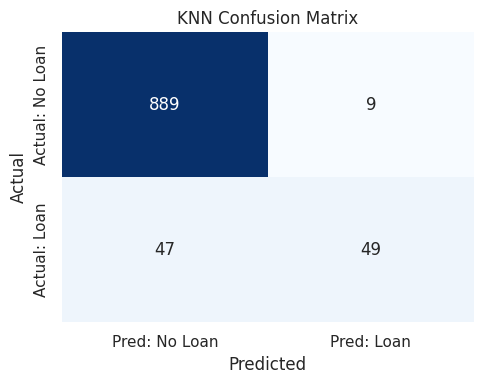

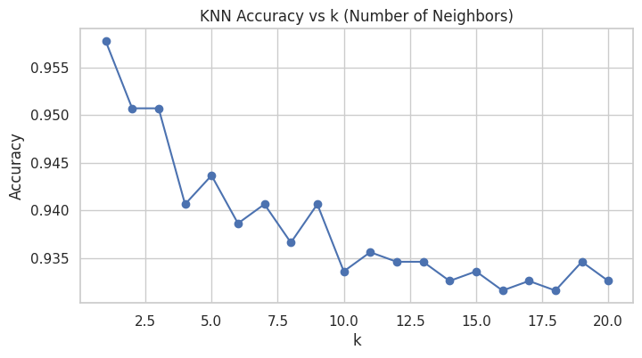

```
Naive scan → best k ≈ 1, accuracy = 0.9577


=================================================================
MODEL 2 — Random Forest
=================================================================

✅ Model trained (100 trees)

📊 Random Forest Evaluation Metrics
Accuracy : 0.9940
Precision: 0.9891
Recall   : 0.9479
F1 score : 0.9681
ROC AUC  : 0.9997

Classification Report:
              precision    recall  f1-score   support

           0       0.99      1.00      1.00       898
           1       0.99      0.95      0.97        96

    accuracy                           0.99       994
   macro avg       0.99      0.97      0.98       994
weighted avg       0.99      0.99      0.99       994
```

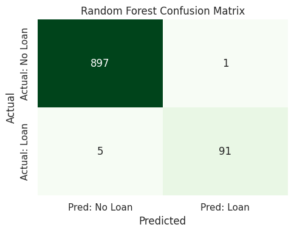

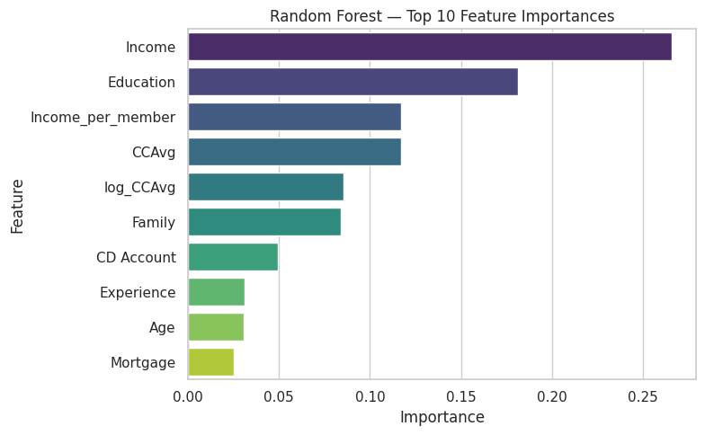

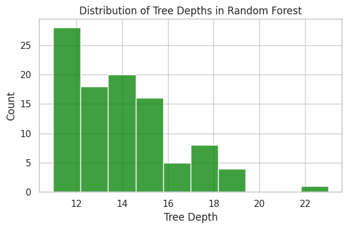

```
=== Summary of Model 1 & Model 2 Results ===
```

| Model | Notes | Accuracy | Precision | Recall | F1 | ROC_AUC |
| --- | --- | --- | --- | --- | --- | --- |
| KNN | k=5 baseline; best_k≈1 | 0.943662 | 0.844828 | 0.510417 | 0.636364 | 0.946182 |
| Random Forest | 100 trees baseline; importance + tree depth pl... | 0.993964 | 0.989130 | 0.947917 | 0.968085 | 0.999710 |

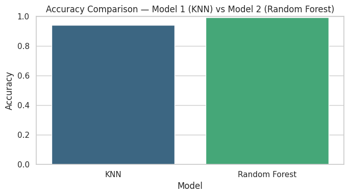

```
You can discuss insights from these results in Section 3.3.
```

```python
# =============================================================
# SECTION 3.2 — Naive Models and Evaluation
# Model 1: K-Nearest Neighbors (KNN)
# Model 2: Random Forest
# =============================================================

import numpy as np
import pandas as pd
import matplotlib.pyplot as plt
import seaborn as sns
from sklearn.preprocessing import StandardScaler
from sklearn.neighbors import KNeighborsClassifier
from sklearn.ensemble import RandomForestClassifier
from sklearn.metrics import (
    accuracy_score, precision_score, recall_score,
    f1_score, roc_auc_score, classification_report,
    confusion_matrix
)

sns.set(style="whitegrid")
plt.rcParams.update({"figure.figsize": (8,4)})

results = []

# -------------------------------------------------------------
# ===================== MODEL 1 — KNN =========================
# -------------------------------------------------------------
print("\n" + "="*65)
print("MODEL 1 — K-Nearest Neighbors (KNN)")
print("="*65 + "\n")

# 1️⃣ TRAINING
scaler = StandardScaler()
X_train_scaled = scaler.fit_transform(X_train)
X_test_scaled = scaler.transform(X_test)

knn = KNeighborsClassifier(n_neighbors=5)
knn.fit(X_train_scaled, y_train)
print("✅ Model trained (k = 5)\n")

# 2️⃣ EVALUATION
y_pred_knn = knn.predict(X_test_scaled)
y_proba_knn = knn.predict_proba(X_test_scaled)[:,1]

acc = accuracy_score(y_test, y_pred_knn)
prec = precision_score(y_test, y_pred_knn, zero_division=0)
rec = recall_score(y_test, y_pred_knn, zero_division=0)
f1 = f1_score(y_test, y_pred_knn, zero_division=0)
auc = roc_auc_score(y_test, y_proba_knn)

print("📊 KNN Evaluation Metrics")
print(f"Accuracy : {acc:.4f}")
print(f"Precision: {prec:.4f}")
print(f"Recall   : {rec:.4f}")
print(f"F1 score : {f1:.4f}")
print(f"ROC AUC  : {auc:.4f}\n")

print("Classification Report:")
print(classification_report(y_test, y_pred_knn, zero_division=0))

# 🎨 Confusion Matrix Visualization
cm_knn = confusion_matrix(y_test, y_pred_knn)
plt.figure(figsize=(5,4))
sns.heatmap(cm_knn, annot=True, fmt='d', cmap='Blues', cbar=False,
            xticklabels=['Pred: No Loan', 'Pred: Loan'],
            yticklabels=['Actual: No Loan', 'Actual: Loan'])
plt.title("KNN Confusion Matrix")
plt.ylabel("Actual")
plt.xlabel("Predicted")
plt.tight_layout()
plt.show()

# 3️⃣ SMALL EXPERIMENT — Effect of k on accuracy
k_values = range(1, 21)
acc_list = []
for k in k_values:
    model = KNeighborsClassifier(n_neighbors=k)
    model.fit(X_train_scaled, y_train)
    acc_list.append(accuracy_score(y_test, model.predict(X_test_scaled)))

plt.plot(k_values, acc_list, marker='o')
plt.title("KNN Accuracy vs k (Number of Neighbors)")
plt.xlabel("k")
plt.ylabel("Accuracy")
plt.grid(True)
plt.show()

best_k = k_values[int(np.argmax(acc_list))]
print(f"Naive scan → best k ≈ {best_k}, accuracy = {max(acc_list):.4f}\n")

# 4️⃣ RECORD RESULTS
results.append({
    "Model": "KNN",
    "Notes": f"k=5 baseline; best_k≈{best_k}",
    "Accuracy": acc, "Precision": prec, "Recall": rec, "F1": f1, "ROC_AUC": auc
})


# -------------------------------------------------------------
# ================== MODEL 2 — Random Forest ==================
# -------------------------------------------------------------
print("\n" + "="*65)
print("MODEL 2 — Random Forest")
print("="*65 + "\n")

# 1️⃣ TRAINING
rf = RandomForestClassifier(n_estimators=100, random_state=42, n_jobs=-1)
rf.fit(X_train, y_train)
print("✅ Model trained (100 trees)\n")

# 2️⃣ EVALUATION
y_pred_rf = rf.predict(X_test)
y_proba_rf = rf.predict_proba(X_test)[:,1]

acc_rf = accuracy_score(y_test, y_pred_rf)
prec_rf = precision_score(y_test, y_pred_rf, zero_division=0)
rec_rf = recall_score(y_test, y_pred_rf, zero_division=0)
f1_rf = f1_score(y_test, y_pred_rf, zero_division=0)
auc_rf = roc_auc_score(y_test, y_proba_rf)

print("📊 Random Forest Evaluation Metrics")
print(f"Accuracy : {acc_rf:.4f}")
print(f"Precision: {prec_rf:.4f}")
print(f"Recall   : {rec_rf:.4f}")
print(f"F1 score : {f1_rf:.4f}")
print(f"ROC AUC  : {auc_rf:.4f}\n")

print("Classification Report:")
print(classification_report(y_test, y_pred_rf, zero_division=0))

# 🎨 Confusion Matrix Visualization
cm_rf = confusion_matrix(y_test, y_pred_rf)
plt.figure(figsize=(5,4))
sns.heatmap(cm_rf, annot=True, fmt='d', cmap='Greens', cbar=False,
            xticklabels=['Pred: No Loan', 'Pred: Loan'],
            yticklabels=['Actual: No Loan', 'Actual: Loan'])
plt.title("Random Forest Confusion Matrix")
plt.ylabel("Actual")
plt.xlabel("Predicted")
plt.tight_layout()
plt.show()

# 3️⃣ SMALL EXPERIMENT — Feature Importance + Tree Depth Distribution
fi = pd.Series(rf.feature_importances_, index=X.columns).sort_values(ascending=False)
plt.figure(figsize=(8,5))
sns.barplot(x=fi.values[:10], y=fi.index[:10], palette="viridis")
plt.title("Random Forest — Top 10 Feature Importances")
plt.xlabel("Importance")
plt.ylabel("Feature")
plt.tight_layout()
plt.show()

tree_depths = [estimator.tree_.max_depth for estimator in rf.estimators_]
plt.figure(figsize=(6,4))
sns.histplot(tree_depths, bins=10, kde=False, color="green")
plt.title("Distribution of Tree Depths in Random Forest")
plt.xlabel("Tree Depth")
plt.ylabel("Count")
plt.tight_layout()
plt.show()

# 4️⃣ RECORD RESULTS
results.append({
    "Model": "Random Forest",
    "Notes": "100 trees baseline; importance + tree depth plotted",
    "Accuracy": acc_rf, "Precision": prec_rf, "Recall": rec_rf, "F1": f1_rf, "ROC_AUC": auc_rf
})


# -------------------------------------------------------------
# ✅ Summary of both models
# -------------------------------------------------------------
results_df = pd.DataFrame(results).set_index("Model")

print("\n=== Summary of Model 1 & Model 2 Results ===")
display(results_df)

plt.figure(figsize=(7,4))
sns.barplot(
    data=results_df.reset_index(),
    x="Model", y="Accuracy",
    hue="Model", palette="viridis", legend=False
)
plt.title("Accuracy Comparison — Model 1 (KNN) vs Model 2 (Random Forest)")
plt.ylim(0, 1)
plt.tight_layout()
plt.show()

print("\nYou can discuss insights from these results in Section 3.3.")
```

### 3.3 Model Comparisons & Interpretation

**Which model performed better overall, and why?**

> The **Random Forest** model clearly outperformed the K-Nearest Neighbors (KNN) model across all metrics.
> - Random Forest achieved an **accuracy of 0.994**, **F1 = 0.968**, and **ROC AUC = 0.9997**, compared with KNN’s accuracy of 0.944, F1 = 0.636, and ROC AUC = 0.946.
> - The ensemble approach helped Random Forest capture complex nonlinear relationships and interactions among features, leading to much higher recall (0.95 vs 0.51) and overall predictive power.

**Note any limitations, surprises, or ideas for improvement.**

> - **Limitations:** Both models were trained on historical data from a single bank; external validity may be limited. Random Forest could still overfit slightly without cross-validation or pruning.
> - **Surprises:** KNN’s recall was quite low despite decent accuracy, meaning it missed many true loan acceptors.
> - **Ideas for improvement:** Try **hyperparameter tuning** (e.g., `n_estimators`, `max_depth`), test additional ensemble methods such as **Gradient Boosting / XGBoost**, and address class imbalance through stratified sampling or resampling techniques.

## Section 4 — Executive Summary & Business Implications

### 4.2 Business Recommendations

> 1. **Target high-value segments** — focus future marketing on customers with above-average income and credit-card activity.
> 2. **Personalize loan messaging** — highlight flexible loan terms and loyalty benefits for graduate or professional customers to increase conversion.
> 3. **Use model outputs to prioritize outreach** — apply predicted probabilities to rank leads, directing sales resources to the top 10–20 % most likely acceptors.
> 4. **Monitor over-exposure risk** — avoid redundant offers to customers already carrying large mortgages or debt balances, preserving satisfaction and compliance .

### 4.3 Caveats and Next Steps

> - **Limitations:** The model is trained on a single-bank dataset from one period; behavior may differ across regions or economic cycles. Random Forest’s complexity also limits interpretability for direct policy communication.
> - **Risks:** Potential over-reliance on income and spending could bias offers toward affluent groups; continuous fairness monitoring is required.
> - **Next Steps:**  
>   • Perform cross-validation and hyper-parameter tuning (`n_estimators`, `max_depth`) to verify stability.  
>   • Test additional ensemble algorithms such as Gradient Boosting or XGBoost for further lift.  
>   • Incorporate behavioral or digital-channel data to enrich customer segmentation and reduce bias .

## Final Output

```python
!jupyter nbconvert --to html "Final_Project_Example_gc.ipynb"
```

```
[NbConvertApp] Converting notebook Final_Project_Example_gc.ipynb to html
[NbConvertApp] WARNING | Alternative text is missing on 28 image(s).
[NbConvertApp] Writing 2277597 bytes to Final_Project_Example_gc.html
```